# XAI – Exercise 5: Partial Dependence Plots (PDP)

Data Science – Model-Agnostic Methods

mayo 04, 2026

# Introduction

This report applies **Partial Dependence Plots (PDP)** to two real-world prediction tasks. PDP is a model-agnostic global interpretability method that visualises the marginal effect of one or two features on the predicted outcome of a previously fitted model. All models are **Random Forests** fitted using the `randomForest` package.

The partial dependence function is estimated as:

$$\hat{f}_{x_S}(x_S) \approx
\frac{1}{n}\sum_{i=1}^{n}\hat{f}(x_S,\, x_C^{(i)})$$

where $x_S$ is the feature of interest and $x_C$ are the remaining features marginalised over the data. For every plot, a grid of **at least 50 evenly spaced values** is evaluated. Rug marks along the axes represent the empirical distribution of training observations, helping distinguish well-supported regions from potential extrapolations.

# Exercise 1 – 1D PDP: Bike Rental Prediction

## Data Preparation and Model Training

```r
# Libraries
library(randomForest)
library(ggplot2)
library(gridExtra)
library(scales)

# Load data
day <- read.csv("day.csv")

# Create days_since_2011 from the date column
day$days_since_2011 <- as.numeric(
  as.Date(day$dteday) - as.Date("2011-01-01")
)

# Feature set (exclude raw date, id, casual, registered)
features_bike <- c("days_since_2011", "season", "yr", "mnth", "holiday",
                   "weekday", "workingday", "weathersit",
                   "temp", "atemp", "hum", "windspeed")

train_bike <- day[, c(features_bike, "cnt")]

# Fit Random Forest on full bike dataset (731 rows — manageable)
set.seed(42)
rf_bike <- randomForest(cnt ~ ., data = train_bike, ntree = 500)

cat("Random Forest – Bike Rentals\n")
```

```
## Random Forest – Bike Rentals
```

```r
cat("OOB R²:", round(1 - rf_bike$mse[500] / var(day$cnt), 3), "\n")
```

```
## OOB R²: 0.892
```

## PDP Helper Functions

```r
# Generic 1D PDP: evaluates model predictions over a grid of >= 50 values
compute_pdp_1d <- function(model, feature, train_df, n_grid = 50) {
  grid_vals <- seq(min(train_df[[feature]]),
                   max(train_df[[feature]]),
                   length.out = n_grid)
  pdp_vals <- sapply(grid_vals, function(v) {
    tmp            <- train_df
    tmp[[feature]] <- v
    mean(predict(model, newdata = tmp))
  })
  data.frame(x = grid_vals, yhat = pdp_vals)
}

# Plot function matching the class slide style (line + rug)
plot_pdp_bike <- function(pdp_df, x_label, train_df, feature,
                          y_limits = c(0, 5500)) {
  ggplot(pdp_df, aes(x = x, y = yhat)) +
    geom_line(colour = "black", linewidth = 0.9) +
    geom_rug(
      data        = train_df,
      aes_string(x = feature),
      sides       = "b",
      alpha       = 0.4,
      colour      = "black",
      inherit.aes = FALSE
    ) +
    scale_y_continuous(limits = y_limits,
                       breaks = seq(0, 5000, by = 1000)) +
    labs(x = x_label, y = "Predicted number of bike rentals") +
    theme_bw(base_size = 11) +
    theme(panel.grid.minor = element_blank())
}
```

## Results

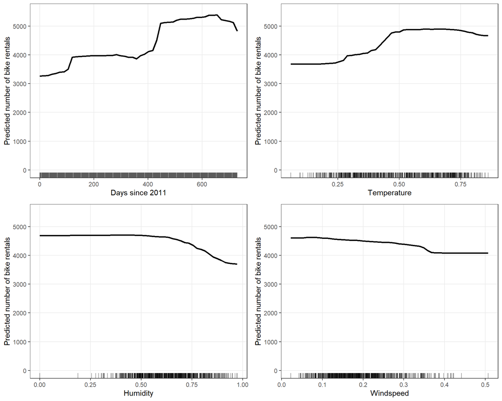

```r
# Compute the four 1D PDPs (50 grid points each)
pdp_days <- compute_pdp_1d(rf_bike, "days_since_2011", train_bike)
pdp_temp <- compute_pdp_1d(rf_bike, "temp",            train_bike)
pdp_hum  <- compute_pdp_1d(rf_bike, "hum",             train_bike)
pdp_wind <- compute_pdp_1d(rf_bike, "windspeed",       train_bike)

# Build plots
p1 <- plot_pdp_bike(pdp_days, "Days since 2011", day, "days_since_2011")
p2 <- plot_pdp_bike(pdp_temp, "Temperature",     day, "temp")
p3 <- plot_pdp_bike(pdp_hum,  "Humidity",        day, "hum")
p4 <- plot_pdp_bike(pdp_wind, "Windspeed",       day, "windspeed")

grid.arrange(p1, p2, p3, p4, ncol = 2)
```